# 2. Exploratory Factor Analysis: Personality Traits

Sirid Wihlborg

# Table of Content

1. Data Cleaning
2. Create correlation matrix
3. perform PCA
4. Merge with ID
5. Display and Export new dataframe to directory

# 1. Data Cleaning

```r
# Loading the full dataset
data_big5_raw <- read_csv("../data/StudentLife/dataset/survey/BigFive.csv")
```

```r
# selecting only the "types=pre"
data_big5 <- data_big5_raw %>% filter(type == "pre")

# disselecting the two first demographic rows
data_big5 <- data_big5 %>% select(-1, -2)


# find unique values in columns
unique(data_big5$`I see myself as someone who...   - 1. Is talkative`)
```

```
## [1] "Agree a little"             "Neither agree nor disagree"
## [3] "Disagree a little"          "Disagree Strongly"
## [5] "Agree strongly"
```

```r
# replacing character string with numeric value
data_big5 <- data_big5 %>% mutate_all(funs(if_else(. == "Disagree Strongly", "1", .)))
data_big5 <- data_big5 %>% mutate_all(funs(if_else(. == "Disagree a little", "2", .)))
data_big5 <- data_big5 %>% mutate_all(funs(if_else(. == "Neither agree nor disagree", "3", .)))
data_big5 <- data_big5 %>% mutate_all(funs(if_else(. == "Agree a little", "4", .)))
data_big5 <- data_big5 %>% mutate_all(funs(if_else(. == "Agree strongly", "5", .)))

# convert all values from character to numeric
data_big5 <- data_big5 %>% mutate_all(funs(as.numeric(.)))

# replace all missing values with 3  (this shoud be discussed)
sum(is.na(data_big5)) # first count amount of missing values
```

```
## [1] 4
```

```r
data_big5 <- data_big5 %>% mutate_all(funs(if_else(is.na(.), 3, .)))

sum(is.na(data_big5)) # make sure there are none left
```

```
## [1] 0
```

# 2. Create correlation matrix

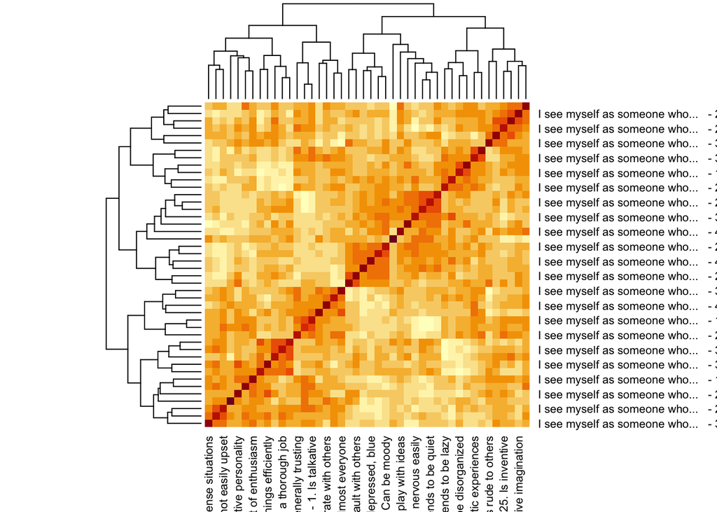

```r
# create a heatmap
heatmap(cor(data_big5))
```

# 3. perform PCA

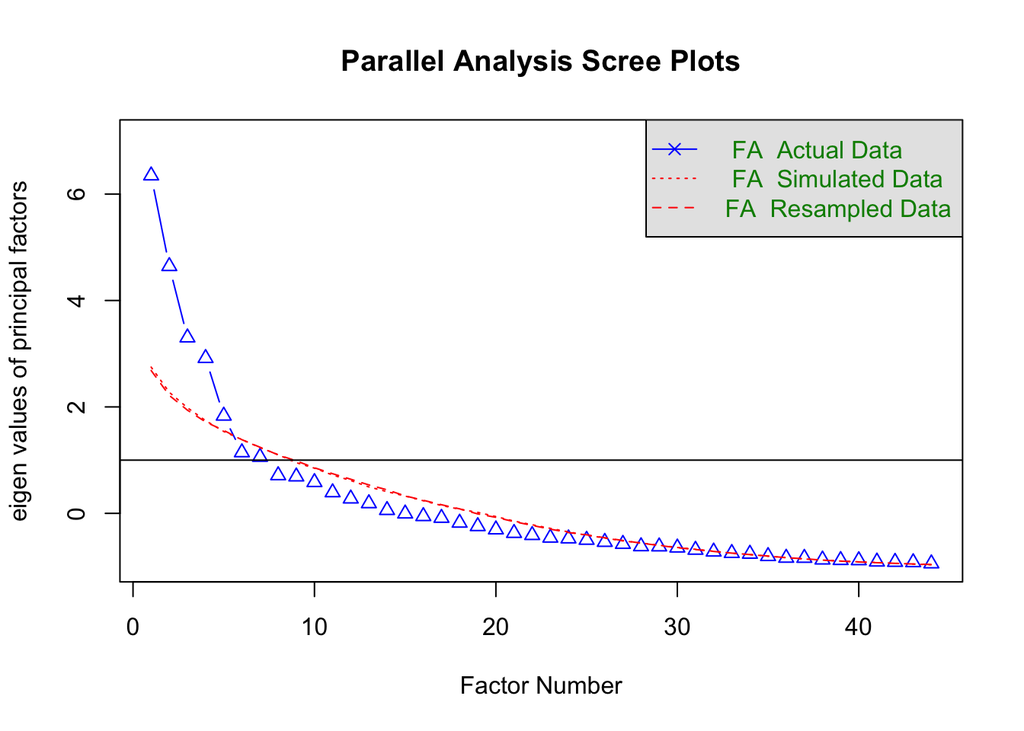

```
## Parallel analysis suggests that the number of factors =  5  and the number of components =  NA
```

```r
fa.parallel(data_big5, fa="fa") # scree plot # 9 factors
```

```r
fa_big5 <- fa(data_big5, 5, rotate="varimax")
print(fa_big5$loadings, cutoff=0.4)
```

```
##
## Loadings:
##                                                                                      MR2
## I see myself as someone who...   - 1. Is talkative
## I see myself as someone who...   - 2. Tends to find fault with others
## I see myself as someone who...   - 3. Does a thorough job                             0.690
## I see myself as someone who...   - 4. Is depressed, blue
## I see myself as someone who...   - 5. Is original, comes up with new ideas
## I see myself as someone who...   - 6. Is reserved
## I see myself as someone who...   - 7. Is helpful and unselfish with others
## I see myself as someone who...   - 8. Can be somewhat careless                       -0.465
## I see myself as someone who...   - 9. Is relaxed, handles stress well.
## I see myself as someone who...   - 10. Is curious about many different things
## I see myself as someone who...   - 11.Is full of energy
## I see myself as someone who...   - 12. Starts quarrels with others
## I see myself as someone who...   - 13. Is a reliable worker                           0.787
## I see myself as someone who...   - 14. Can be tense
## I see myself as someone who...   - 15. Is ingenious, a deep thinker
## I see myself as someone who...   - 16. Generates a lot of enthusiasm
## I see myself as someone who...   - 17. Has a forgiving nature
## I see myself as someone who...   - 18. Tends to be disorganized                      -0.615
## I see myself as someone who...   - 19. Worries a lot
## I see myself as someone who...   - 20. Has an active imagination
## I see myself as someone who...   - 21. Tends to be quiet
## I see myself as someone who...   - 22. Is generally trusting
## I see myself as someone who...   - 23. Tends to be lazy                              -0.694
## I see myself as someone who...   - 24. Is emotionally stable, not easily upset
## I see myself as someone who...   - 25. Is inventive
## I see myself as someone who...   - 26. Has an assertive personality
## I see myself as someone who...   - 27. Can be cold and aloof
## I see myself as someone who...   - 28. Perseveres until the task is finished          0.654
## I see myself as someone who...   - 29. Can be moody
## I see myself as someone who...   - 30. Values artistic, aesthetic experiences
## I see myself as someone who...   - 31. Is sometimes shy, inhibited
## I see myself as someone who...   - 32. Is considerate and kind to almost everyone
## I see myself as someone who...   - 33. Does things efficiently                        0.535
## I see myself as someone who...   - 34. Remains calm in tense situations
## I see myself as someone who...   - 35. Prefers work that is routine
## I see myself as someone who...   - 36. Is outgoing, sociable
## I see myself as someone who...   - 37. Is sometimes rude to others
```

[output cut: 177 more lines]

```
## I see myself as someone who...   - 35. Prefers work that is routine
## I see myself as someone who...   - 36. Is outgoing, sociable
## I see myself as someone who...   - 37. Is sometimes rude to others                   -0.486
## I see myself as someone who...   - 38. Makes plans and follows through with them
## I see myself as someone who...   - 39. Gets nervous easily
## I see myself as someone who...   - 40. Likes to reflect, play with ideas
## I see myself as someone who...   - 41. Has few artistic interests
## I see myself as someone who...   - 42. Likes to cooperate with others                 0.401
## I see myself as someone who...   - 43. Is easily distracted
## I see myself as someone who...   - 44. Is sophisticated in art, music, or literature  0.491
##
##                  MR2   MR1   MR5   MR3   MR4
## SS loadings    4.561 4.471 4.392 3.864 3.714
## Proportion Var 0.104 0.102 0.100 0.088 0.084
## Cumulative Var 0.104 0.205 0.305 0.393 0.477
```

MR2: Does a thorough job 0.690 Is a reliable worker 0.787 Tends to be disorganized -0.615 Tends to be lazy -0.694 Perseveres until the task is finished 0.654 Does things efficiently 0.535 Makes plans and follows through with them 0.707 Is easily distracted -0.570

MR1: Tends to find fault with others 0.658 Is relaxed, handles stress well. -0.588 Worries a lot 0.680 Is emotionally stable, not easily upset -0.508 Can be moody 0.700

MR5: Is talkative -0.614 Is reserved 0.797 Tends to be quiet 0.799 Has an assertive personality -0.532 Is sometimes shy, inhibited 0.679 Is outgoing, sociable -0.688

MR3: Is original, comes up with new ideas 0.806 Is curious about many different things 0.580 Is ingenious, a deep thinker 0.608 Has an active imagination 0.607

MR4: Is helpful and unselfish with others 0.566 Has a forgiving nature 0.587 Is generally trusting 0.530 Values artistic, aesthetic experiences 0.619 Is considerate and kind to almost everyone 0.780

The Big 5 Trades are: Openness, Conscientiousness, Extraversion, Agreeableness, and Neuroticism

MR1 = Neuroticism MR2 = Conscientiousness MR3 = Openness MR4 = Agreeableness MR5 = Extraversion (inverted)

# 4. Merge with ID

```r
fa_big5$scores
```

```
##               MR2         MR1         MR5         MR3         MR4
##  [1,]  0.01575243  0.84094840  0.15870162  1.56498770 -0.85378953
##  [2,]  1.22872423 -0.31132445 -0.41097816  0.76239567  0.48951094
##  [3,]  1.11843263  1.21050344  0.23686791 -1.02781818  0.27721477
##  [4,]  0.69297990  0.99845959  1.49882070 -2.49472216 -1.13935518
##  [5,] -1.39428973  1.30307760  0.26142799 -1.60964529 -1.07825791
##  [6,]  0.95725890 -0.77682747 -1.35610668  0.29159734  0.89134329
##  [7,]  0.77900542 -0.80404642 -0.21955071 -2.33405607 -0.28652733
##  [8,]  0.56529392 -0.43724143 -0.52378967  0.34505091 -0.37232166
##  [9,] -1.25893773 -2.31539166  0.09268862  0.92249415  0.07479775
## [10,]  1.91398230  1.06801538  0.22950851  1.11074180 -3.01072370
## [11,] -0.19123728 -0.88996438 -0.82073649  0.80053841 -1.10455397
## [12,] -0.95382589  0.99383641 -0.17353161  1.57934335  0.26576838
## [13,]  0.53397498  0.15394570  1.04098687 -1.09102636  0.37536065
## [14,]  0.36122625  0.22693354  0.62677907 -0.95962453 -0.14402421
```

[output cut: 32 more lines]

```r
df_big5 <- cbind(data_big5_raw$uid, fa_big5$scores)
df_big5 <- as.data.frame(df_big5)
df_big5[,-1] <- lapply(df_big5[,-1], as.numeric) # make all values numeric (except the ID)

df_big5 <- rename(df_big5, "ID" = "V1", "Neuroticism" = "MR1", "Conscientiousness" = "MR2", "Openness" = "MR3", "Agreeableness" = "MR4", "Extraversion" = "MR5")

# obs: as the Extraversion column is inverted, we'll just changed the signs of the values in that column
df_big5$Extraversion <- (df_big5$Extraversion)*-1
```

# 5. Display and Export new dataframe to directory

```r
df_big5
```

```
##     ID Conscientiousness Neuroticism Extraversion    Openness Agreeableness
## 1  u00        0.01575243  0.84094840  -0.15870162  1.56498770   -0.85378953
## 2  u01        1.22872423 -0.31132445   0.41097816  0.76239567    0.48951094
## 3  u02        1.11843263  1.21050344  -0.23686791 -1.02781818    0.27721477
## 4  u03        0.69297990  0.99845959  -1.49882070 -2.49472216   -1.13935518
## 5  u04       -1.39428973  1.30307760  -0.26142799 -1.60964529   -1.07825791
## 6  u05        0.95725890 -0.77682747   1.35610668  0.29159734    0.89134329
## 7  u07        0.77900542 -0.80404642   0.21955071 -2.33405607   -0.28652733
## 8  u08        0.56529392 -0.43724143   0.52378967  0.34505091   -0.37232166
## 9  u09       -1.25893773 -2.31539166  -0.09268862  0.92249415    0.07479775
## 10 u10        1.91398230  1.06801538  -0.22950851  1.11074180   -3.01072370
## 11 u12       -0.19123728 -0.88996438   0.82073649  0.80053841   -1.10455397
## 12 u13       -0.95382589  0.99383641   0.17353161  1.57934335    0.26576838
## 13 u14        0.53397498  0.15394570  -1.04098687 -1.09102636    0.37536065
## 14 u15        0.36122625  0.22693354  -0.62677907 -0.95962453   -0.14402421
```

[output cut: 32 more lines]

```r
write.csv(df_big5, "../df/df_big5.csv")
```